# Optimizing Corporate Training: A Predictive Model for Maximizing Effectiveness

Data-Driven Insights for Global Secure Insurance

Authors: Gutierrez Fernandez, Jesus Osmar & Marcelo Porcayo, Tonancy Lizahaya

October 21, 2025

## The challenge we are facing is to invest wisely in employee development

Global Secure Insurance allocates substantial resources to training and development. However, it is important to ensure that these resources are being used effectively. Traditional, one-size-fits-all approaches often produce inconsistent results, particularly when working with a diverse, multigenerational workforce. We posed the following question: **The objective is to ascertain whether it is possible to use data to predict training success and tailor programmes for maximum impact.**

By analysing data from 500 employee training records, we were able to move beyond assumptions and build a predictive model that identifies the key drivers of learning effectiveness.

## Key Finding: The impact of age varies according to the specific modality.

Our analysis revealed a crucial interaction: the effectiveness of training modes depends significantly on employee age.

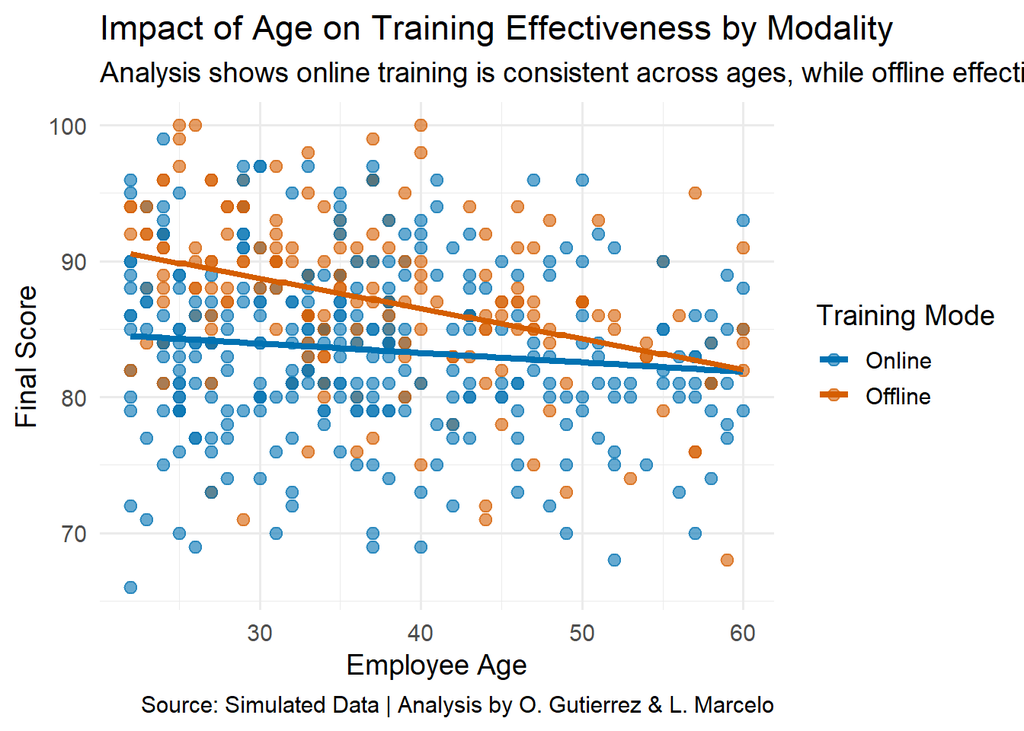

The data clearly shows:

- **Online Training:** The effectiveness of the product is consistent across all age groups. The blue trend line, which indicates the performance of younger and older employees, is almost flat, suggesting that both age demographics achieve similar levels of success online.
- **Offline (Presencial) Training:** While this approach is highly effective for younger employees (under 40), its advantage diminishes significantly with age. The orange trend line indicates a steeper decline.

This counterintuitive finding suggests that **online** **training is the most reliable and efficient baseline** for diverse teams, while **offline training is a high-impact tool best reserved for specific situations**, particularly for maximising the potential of junior talent.

## The Solution: A Predictive “Effectiveness Simulator”

Following analysis of the available data, a predictive model was constructed. This model, which employs linear regression (R² ≈ 0.75), has been shown to forecast an employee’s final training score with a high degree of accuracy (average error ~3.2 points).

This model powers a practical tool: the “Effectiveness Simulator”. This enables managers and trainers to:

Input an employee’s profile (age, education, pre-score).

1. Instantly see the predicted score for both Online and Offline modalities.
2. Make data-driven decisions on the most effective training approach for individuals or teams.

By shifting from a one-size-fits-all model to a **personalised, data-informed training design**, Global Secure Insurance can enhance learning outcomes, optimise resource allocation, and maximise the ROI of its development programs.

Interactive Demo: The Effectiveness Simulator v2.0

Watch this short video demonstrating the predictive tool in action:

[video not shown]